The Youtube video link: https://youtu.be/Z9tzkhsKxzI

# Library

```python
import pandas as pd
import numpy as np
import seaborn as sns
import matplotlib.pyplot as plt
import collections
import geopandas as gpd
```

```python
data1 = pd.read_parquet('/content/yellow_tripdata_2023-01.parquet')
data3 = pd.read_parquet('/content/yellow_tripdata_2023-03.parquet')
data6 = pd.read_parquet('/content/yellow_tripdata_2023-06.parquet')
```

# **Task 1: Data Loading**

**Data length**

```python
print("""The length of 3 datasets:
January: {}
March: {}
June: {}""".format(len(data1),len(data3),len(data6)))
```

```
The length of 3 datasets:
January: 3066766
March: 3403766
June: 3307234
```

**Check the columns's name**

```python
data1.columns
```

```
Index(['VendorID', 'tpep_pickup_datetime', 'tpep_dropoff_datetime',
       'passenger_count', 'trip_distance', 'RatecodeID', 'store_and_fwd_flag',
       'PULocationID', 'DOLocationID', 'payment_type', 'fare_amount', 'extra',
       'mta_tax', 'tip_amount', 'tolls_amount', 'improvement_surcharge',
       'total_amount', 'congestion_surcharge', 'airport_fee'],
      dtype='object')
```

```python
data3.columns
```

```
Index(['VendorID', 'tpep_pickup_datetime', 'tpep_dropoff_datetime',
       'passenger_count', 'trip_distance', 'RatecodeID', 'store_and_fwd_flag',
       'PULocationID', 'DOLocationID', 'payment_type', 'fare_amount', 'extra',
       'mta_tax', 'tip_amount', 'tolls_amount', 'improvement_surcharge',
       'total_amount', 'congestion_surcharge', 'Airport_fee'],
      dtype='object')
```

```python
data6.columns
```

```
Index(['VendorID', 'tpep_pickup_datetime', 'tpep_dropoff_datetime',
       'passenger_count', 'trip_distance', 'RatecodeID', 'store_and_fwd_flag',
       'PULocationID', 'DOLocationID', 'payment_type', 'fare_amount', 'extra',
       'mta_tax', 'tip_amount', 'tolls_amount', 'improvement_surcharge',
       'total_amount', 'congestion_surcharge', 'Airport_fee'],
      dtype='object')
```

According to the columns' name of the 3 yellow Taxi's data, it is clear that no new features is added to make the different. Where the each columns is present for:

| Feature | Description |
| --- | --- |
| `VendorID` | A code indicating the TPEP provider that provided the record. 1= Creative Mobile Technologies, LLC; 2= VeriFone Inc |
| `tpep_pickup_datetime` | The date and time when the meter was engaged. |
| `tpep_dropoff_datetime` | The date and time when the meter was disengaged. |
| `passenger_count` | The number of passengers in the vehicle. This is a driver-entered value. |
| `trip_distance` | The elapsed trip distance in miles reported by the taximeter. |
| `RatecodeID` | The final rate code in effect at the end of the trip. 1= Standard rate 2= JFK 3= Newark 4= Nassau or Westchester 5= Negotiated fare 6= Group ride |
| `store_and_fwd_flag` | This flag indicates whether the trip record was held in vehicle memory before sending to the vendor, aka “store and forward,” because the vehicle did not have a connection to the server. Y= store and … |
| `PULocationID` | TLC Taxi Zone in which the taximeter was engaged |
| `DOLocationID` | TLC Taxi Zone in which the taximeter was disengaged |
| `payment_type` | A numeric code signifying how the passenger paid for the trip. 0= Credit card 1= Cash 2= No charge 3= Dispute 4= Unknown 5=Voided trip |
| `fare_amount` | The time-and-distance fare calculated by the meter. |
| `extra` | Miscellaneous extras and surcharges. Currently, this only includes the \$0.50 and \$1 rush hour and overnight charges. |
| `mta_tax` | \$0.50 MTA tax that is automatically triggered based on the metered rate in use. |
| `tip_amount` | This field is automatically populated for credit card tips. Cash tips are not included. |
| `tolls_amount` | Total amount of all tolls paid in trip. |
| `improvement_surcharge` | \$0.30 improvement surcharge assessed trips at the flag drop. The improvement surcharge began being levied in 2015. |
| `total_amount` | The total amount charged to passengers. Does not include cash tips. |
| `congestion_surcharge` | Total amount collected in trip for NYS congestion surcharge. |
| `Airport_fee` | \$1.25 for pick up only at LaGuardia and John F. Kennedy Airports |

**Merge data and analyze the trend through 3 months**

```python
# Add new columns month to make it specific, because the data will be merege later
data1['month'] = 'January'
data3['month'] = 'March'
data6['month'] = 'June'
# Change the airport_fee to Airport_fee to make it the same as March and June data
data1.rename(columns={"airport_fee": "Airport_fee"}, inplace=True)
# Merge 3 data to 1 to analyze
data_merge = pd.concat([data1, data3, data6], ignore_index=True)
```

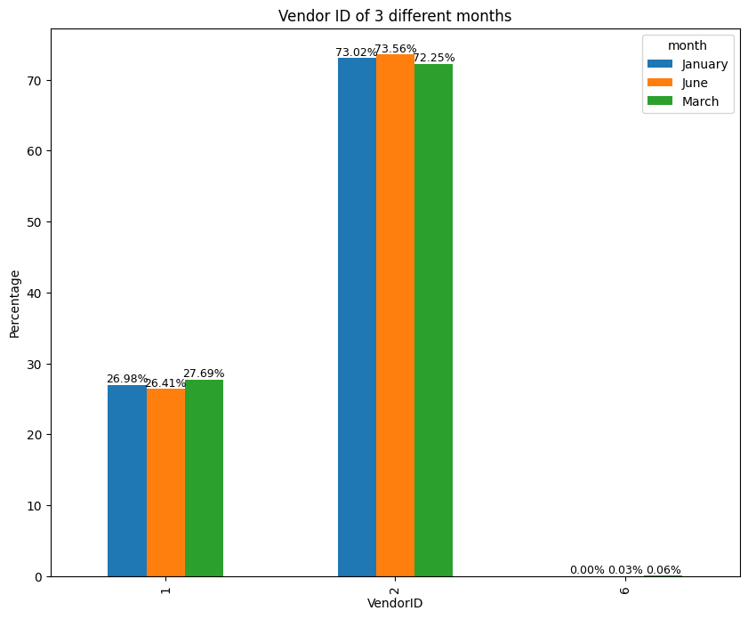

```python
Vendor_month = data_merge.groupby(['VendorID', 'month']).size().unstack(fill_value=0)  # Group VendorID and month
Vendor_month_percent = Vendor_month.div(Vendor_month.sum(axis=0), axis=1) * 100  # Get the percentage of VendorID per month

# Plot the bar plot
ax = Vendor_month_percent.plot(kind='bar', figsize=(10, 8))
plt.title('Vendor ID of 3 different months')
plt.xlabel('VendorID')
plt.ylabel('Percentage')

# Add number of percentage
for p in ax.patches:
    ax.annotate(f'{p.get_height():.2f}%', (p.get_x() + p.get_width()/2., p.get_height()), ha='center', va='bottom', fontsize=9)
plt.show()
```

According to this plot, the percentage of `VendorID` is not much different through 3 months. There are only one specific value which is the `VendorID` equal to 6 is only appears in March and June. However, this value is not much, compare to the value 1 and 2 of `VendorID`

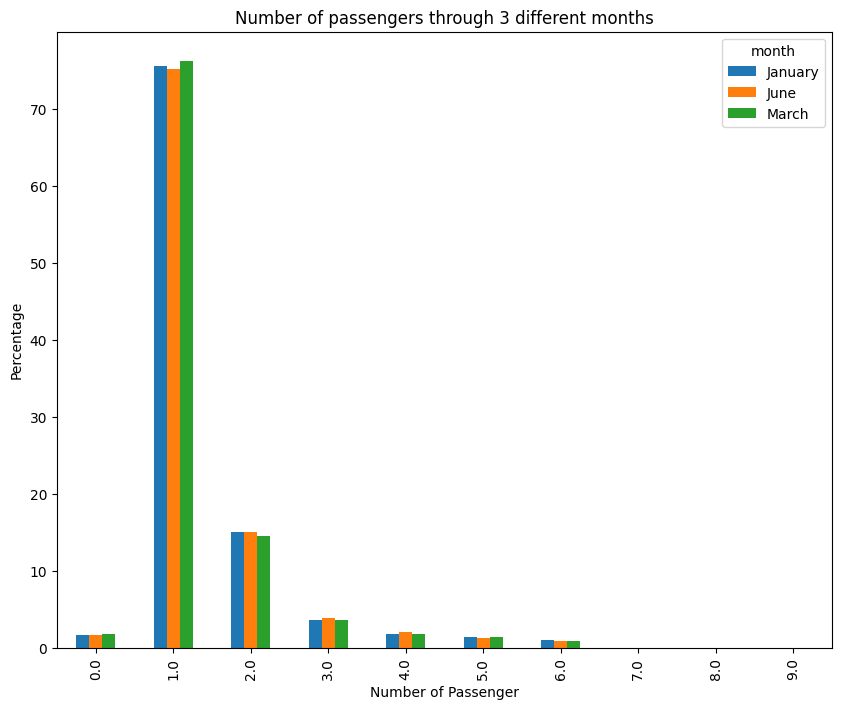

```python
# Group 2 variable 'passenger_count', 'month'
Passenger_month = data_merge.groupby(['passenger_count', 'month']).size().unstack(fill_value=0)
# Devide to get the percentage, this help the plot dont rely on the total number oftrip per month
Passenger_month_percent = Passenger_month.div(Passenger_month.sum(axis=0), axis=1) * 100

# Use barchart to plot data
ax = Passenger_month_percent.plot(kind='bar', figsize=(10, 8))
plt.title('Number of passengers through 3 different months')
plt.xlabel('Number of Passenger')
plt.ylabel('Percentage')
plt.show()
```

According to the plot, there is not much different between 3 months on the number of passensers, in which most of them are 1 or 2 passengers in one trip

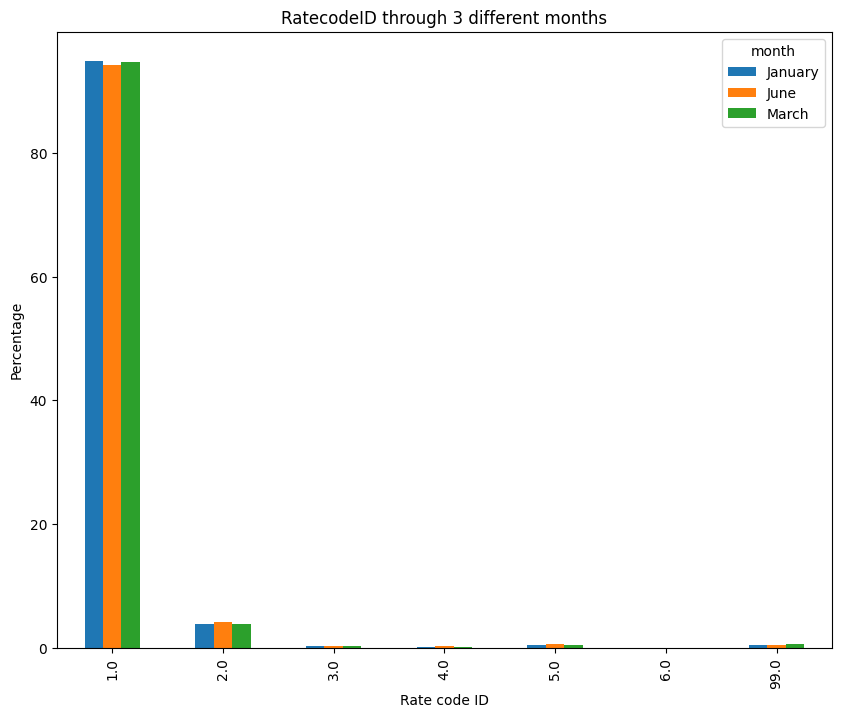

```python
rateID_month = data_merge.groupby(['RatecodeID', 'month']).size().unstack(fill_value=0)  # Group RatecodeID and month
# Devide to get the percentage, this help the plot dont rely on the total number of trip per month
rateID_month_percent = rateID_month.div(rateID_month.sum(axis=0), axis=1) * 100

# Use barchart to plot data
ax = rateID_month_percent.plot(kind='bar', figsize=(10, 8))
plt.title('RatecodeID through 3 different months')
plt.xlabel('Rate code ID')
plt.ylabel('Percentage')
plt.show()
```

According to the plot, there is not much different between 3 months on the RatecodeID. Therefore, most of the final rate code at the end of trip is 1, which mean most of rate code is standard rate, follow up with JKF (code = 2).

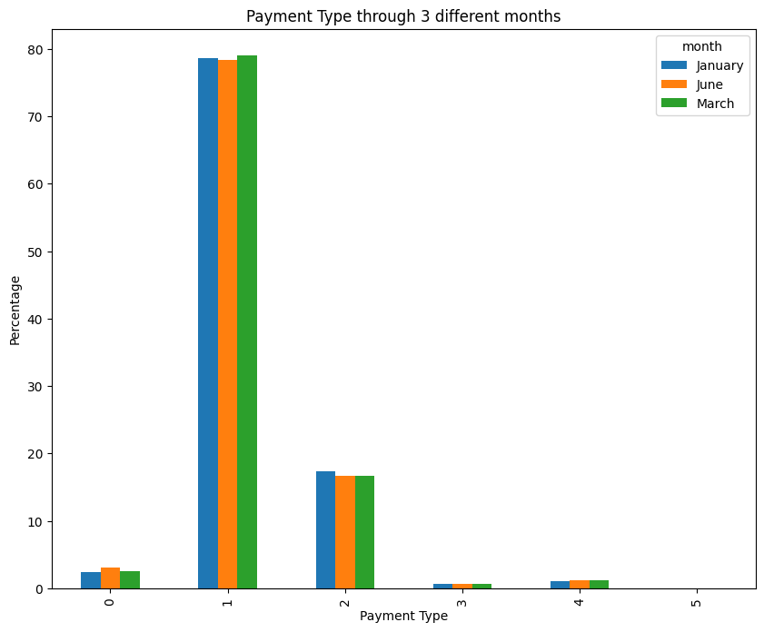

```python
Paytype_month = data_merge.groupby(['payment_type', 'month']).size().unstack(fill_value=0)  # Group payment_type and month
Paytype_month_percent = Paytype_month.div(Paytype_month.sum(axis=0), axis=1) * 100  # Get the percentage of VendorID per month

# Use barchart to plot data
ax = Paytype_month_percent.plot(kind='bar', figsize=(10, 8))
plt.title('Payment Type through 3 different months')
plt.xlabel('Payment Type')
plt.ylabel('Percentage')
plt.show()
```

According to the plot, there is no different between 3 months on the Payment Type. Therefore, most of the payment type is by cash with the code 1, and the second highest payment type is no charge. Then, code 0 ranks at the third, and then follow up by unknown and dispute.

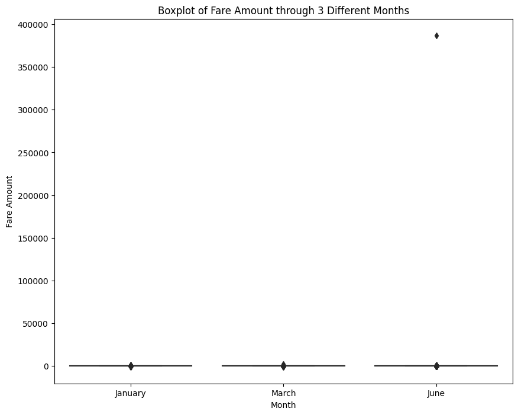

```python
plt.figure(figsize=(10, 8))  # Set the size of the plot
sns.boxplot(x='month', y='fare_amount', data=data_merge, palette=["blue", "red", "green"])  # Plot the boxplot of month and fare amount
plt.title('Boxplot of Fare Amount through 3 Different Months')
plt.xlabel('Month')
plt.ylabel('Fare Amount')
plt.show()
```

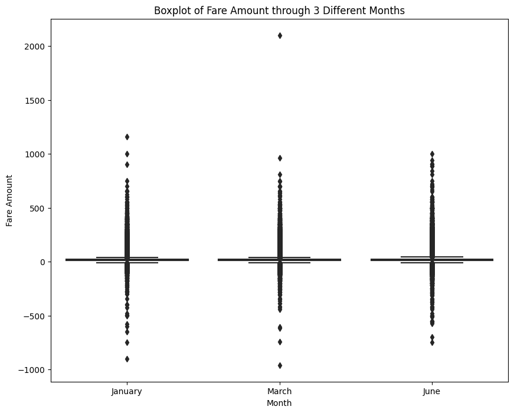

```python
# remove the extreme outlier in June
data_merge = data_merge[data_merge['fare_amount'] <= 300000]
plt.figure(figsize=(10, 8))
sns.boxplot(x='month', y='fare_amount', data=data_merge, palette=["blue", "red", "green"])
plt.title('Boxplot of Fare Amount through 3 Different Months')
plt.xlabel('Month')
plt.ylabel('Fare Amount')
plt.show()
```

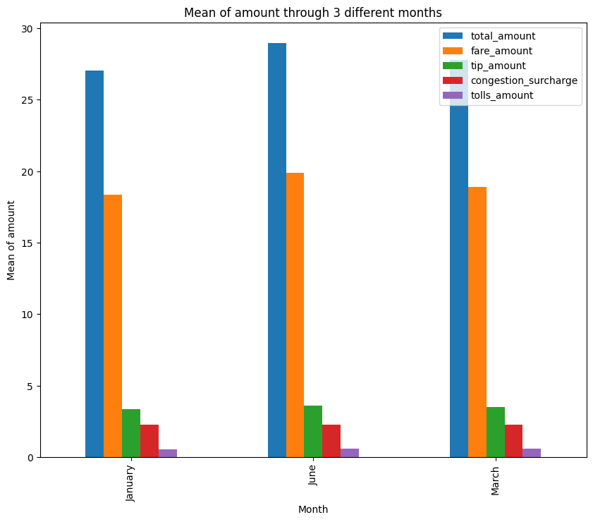

```python
# Group by month to check the mean of some money amount per month, and plot the graph
data_merge.groupby(['month'])[['total_amount','fare_amount','tip_amount','congestion_surcharge','tolls_amount']].mean().plot(kind='bar', figsize=(10, 8))
plt.title('Mean of amount through 3 different months')
plt.xlabel('Month')
plt.ylabel('Mean of amount')
plt.show()
```

According to some plots of amounts through 3 different months, it is clear that June have gain more money than the other 2 months and there is an extreme outlier in June, which is removed to support for the better display.

**Conclusion:**

According to some category variable plots, including **VendorID, RatecodeID, Payment Type,** and **Number of passenger** as percentage, they show the clear similarity through all 3 months and not much differences have been recorded. However, in **VendorID** there is new ID, which is equal to 6 have been found in March and June.

In conclusion, the trends of **VendorID, RatecodeID, Payment Type,** and **Number of passenger** is not have the significant differences through 3 months, but the amount income is increase from January to June

# **Task 2: Data Exploration and Pre-processing**

## **1. Check for missing values in the dataset. Handle them appropriately and explain why you used a certain strategy?**

```python
# Call the data as January data
data = pd.read_parquet('/content/yellow_tripdata_2023-01.parquet')
data.shape
```

```
(3066766, 19)
```

```python
data.isna().sum() # Check the number of null value
```

```
VendorID                     0
tpep_pickup_datetime         0
tpep_dropoff_datetime        0
passenger_count          71743
trip_distance                0
RatecodeID               71743
store_and_fwd_flag       71743
PULocationID                 0
DOLocationID                 0
payment_type                 0
fare_amount                  0
extra                        0
mta_tax                      0
tip_amount                   0
tolls_amount                 0
improvement_surcharge        0
total_amount                 0
congestion_surcharge     71743
airport_fee              71743
dtype: int64
```

There are 5 features that have the null value, which is **passenger_count, RatecodeID, RatecodeID, store_and_fwd_flag, congestion_surcharge, and airport_fee** with the same amount 71743 objects are missing.

```python
data[data['passenger_count'].isna()].isna().sum() # Check the number of null value based on passenger_count
```

```
VendorID                     0
tpep_pickup_datetime         0
tpep_dropoff_datetime        0
passenger_count          71743
trip_distance                0
RatecodeID               71743
store_and_fwd_flag       71743
PULocationID                 0
DOLocationID                 0
payment_type                 0
fare_amount                  0
extra                        0
mta_tax                      0
tip_amount                   0
tolls_amount                 0
improvement_surcharge        0
total_amount                 0
congestion_surcharge     71743
airport_fee              71743
dtype: int64
```

All the trips for which the 'passenger_count' is null also have the other four features as null. Therefore, all the trips that have null values is occurs together with 'passenger_count', so remove all the null value should be chosed to applied, because all the null values only account for approximately 2.3 percent of the total data (71743 out of 3,066,766, equivalent to 2.339%)

```python
data = data.dropna() # Drop null value
data.isna().sum()
```

```
VendorID                 0
tpep_pickup_datetime     0
tpep_dropoff_datetime    0
passenger_count          0
trip_distance            0
RatecodeID               0
store_and_fwd_flag       0
PULocationID             0
DOLocationID             0
payment_type             0
fare_amount              0
extra                    0
mta_tax                  0
tip_amount               0
tolls_amount             0
improvement_surcharge    0
total_amount             0
congestion_surcharge     0
airport_fee              0
dtype: int64
```

## **2. Identify two columns that have “noisy” (erroneous) values. Explain why you think they are noisy. Identify how many such values exist in the dataset.**

```python
# Check the set of value for each fetures that is numeric.
# By checking these, the anomaly value can be found
for name in data.columns[0:10]:                   # This mean the money amount is not included
    if data[name].dtype != 'datetime64[ns]':      # Time pick up and time drop out is not included
        list_val = []
        for val in set(data[name]):
            list_val.append(val)
        print(name, sorted(list_val))
```

```
VendorID [1, 2]
passenger_count [0.0, 1.0, 2.0, 3.0, 4.0, 5.0, 6.0, 7.0, 8.0, 9.0]
trip_distance [0.0, 0.01, 0.02, 0.03, 0.04, 0.05, 0.06, 0.07, 0.08, 0.09, 0.1, 0.11, 0.12, 0.13, 0.14, 0.15, 0.16, 0.17, 0.18, 0.19, 0.2, 0.21, 0.22, 0.23, 0.24, 0.25, 0.26, 0.27, 0.28, 0.29, 0.3, 0.31, 0.32, 0.33, 0.34, 0.35, 0.36, 0.37, 0.38, 0.39, 0.4, 0.41, 0.42, 0.43, 0.44, 0.45, 0.46, 0.47, 0.…
RatecodeID [1.0, 2.0, 3.0, 4.0, 5.0, 6.0, 99.0]
store_and_fwd_flag ['N', 'Y']
PULocationID [1, 2, 3, 4, 5, 6, 7, 8, 9, 10, 11, 12, 13, 14, 15, 16, 17, 18, 19, 20, 21, 22, 23, 24, 25, 26, 28, 29, 30, 31, 32, 33, 34, 35, 36, 37, 38, 39, 40, 41, 42, 43, 44, 45, 46, 47, 48, 49, 50, 51, 52, 53, 54, 55, 56, 57, 60, 61, 62, 63, 64, 65, 66, 67, 68, 69, 70, 71, 72, 73, 74, 75, 76, 77,…
DOLocationID [1, 2, 3, 4, 5, 6, 7, 8, 9, 10, 11, 12, 13, 14, 15, 16, 17, 18, 19, 20, 21, 22, 23, 24, 25, 26, 27, 28, 29, 30, 31, 32, 33, 34, 35, 36, 37, 38, 39, 40, 41, 42, 43, 44, 45, 46, 47, 48, 49, 50, 51, 52, 53, 54, 55, 56, 57, 58, 59, 60, 61, 62, 63, 64, 65, 66, 67, 68, 69, 70, 71, 72, 73, 74,…
payment_type [1, 2, 3, 4]
```

```python
# Number of the 3 noisy value of features
trip_fre = data[data['trip_distance'] == 0]['trip_distance'].value_counts()
passenger_fre = data[data['passenger_count'] == 0]['passenger_count'].value_counts()
RatecodeID_fre = data[data['RatecodeID'] == 99.0]['RatecodeID'].value_counts()
print('Number of 0 distance trip: ',trip_fre.values[0])
print('Number of 0 passenger trip: ',passenger_fre.values[0])
print('Number of code 99 RatecodeID trip: ',RatecodeID_fre.values[0])
```

```
Number of 0 distance trip:  38367
Number of 0 passenger trip:  51164
Number of code 99 RatecodeID trip:  13106
```

**Check the total income on them**

```python
data[data['trip_distance'] == 0]['total_amount'].sum()
```

```
1184601.11
```

```python
data[data['passenger_count'] == 0]['total_amount'].sum()
```

```
1236230.89
```

```python
data[data['RatecodeID'] == 99.0]['total_amount'].sum()
```

```
494942.07
```

According to the set values of each feature including `VendorID`, `passenger_count`, `trip_distance`, `RatecodeID`, `store_and_fwd_flag`, `PULocationID`, `DOLocationID`, `payment_type`; there are 3 values that are uncommon including `passenger_count` equal to 0, `trip_distance` = 0, and `RatecodeID` with value 99.

The reason why these 3 columns are uncommon are the trip cannot be 0 miles, the trip of taxi cannot be hold if there is no passenger and the `RatecodeID` with value 99 which is not include in the category.

Moreover, when the total amount of the trips, which have no passenger or 0 miles distances, the sum of total amount way more than 0. However, the number of passenger on a trip can only be entered by taxi drivers, this can be the mistake of them.

As a result, these 2 columns `RatecodeID`, `trip_distance` should be the 2 columns that contain the noisy values.

## **3. Identify 2 columns that are highly correlated and explain their correlation**

**Drop all the noisy value in data**

```python
# Drop all the noisy value in data
data = data.loc[(data['RatecodeID'] != 99.0) & (data['trip_distance'] != 0)]
data.shape
```

```
(2945438, 19)
```

**Convert all negative value to possitive**

```python
# Convert all negative value to possitive
data = data.applymap(lambda x: abs(x) if isinstance(x, (int, float)) else x)
data.shape
```

```
(2945438, 19)
```

```python
# Create a copy of data
corr_data = data.copy(deep = True)

# Clean the corr_data to reduce the extreme outliers
data = data[(data['trip_distance'] < 1000) & (data['trip_distance'] > 0)]
data = data[(data['fare_amount'] < 1000)]

corr_data = data.copy(deep = True)
```

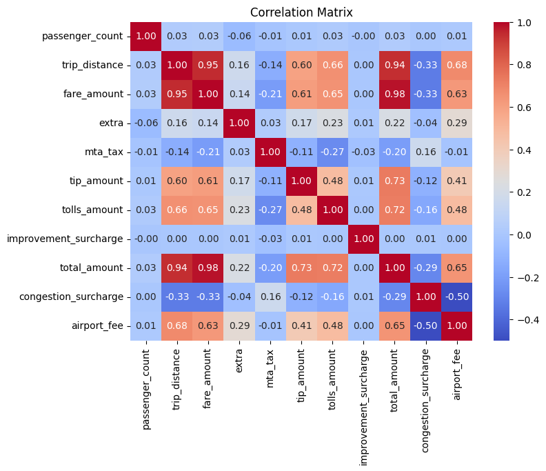

```python
corr_data = corr_data.drop(['VendorID','RatecodeID','PULocationID','DOLocationID','payment_type',\
                            'store_and_fwd_flag','tpep_pickup_datetime', 'tpep_dropoff_datetime'], axis = 1)
correlation_matrix = corr_data.corr()
plt.figure(figsize=(8, 6))
sns.heatmap(correlation_matrix, annot=True, cmap='coolwarm', fmt=".2f")
plt.title("Correlation Matrix")
plt.show()
```

According to the correlation heat map of data on all features except datetime and not like number type, there are 3 pairs of `fare_amount` and `total_amount`, `fare_amount` and `trip_distance`, `trip_distance` and `total_amount` that show the high correlation on the other. In which, the correlation of the pair `fare_amount` and `total_amount` is 0.98, which is the highest correlation, meaning they have the very strong possitive correlation. Thus, if the value in `fare_amount` increase, the `total_amount` will increase as well. Hence, `fare_amount` and `total_amount` are the 2 have highly correlation.

```python
# prompt: fix svm model to predict total_amount of data by other feature

from sklearn import svm
from sklearn.model_selection import train_test_split
from sklearn.metrics import mean_squared_error
from sklearn.preprocessing import StandardScaler
from sklearn.model_selection import GridSearchCV

# Split the data into training and testing sets
X_train, X_test, y_train, y_test = train_test_split(data.drop('total_amount', axis=1), data['total_amount'], test_size=0.25)

# Scale the data
scaler = StandardScaler()
X_train = scaler.fit_transform(X_train)
X_test = scaler.transform(X_test)

# Create the SVM model
model = svm.SVR()

# Hyperparameter tuning
parameters = {'C': [0.1, 1, 10, 100, 1000], 'gamma': [0.001, 0.01, 0.1, 1, 10]}
grid_search = GridSearchCV(model, parameters, cv=5)
grid_search.fit(X_train, y_train)

# Make predictions on the test set
y_pred = grid_search.predict(X_test)

# Evaluate the model
mse = mean_squared_error(y_test, y_pred)
print('Mean squared error:', mse)

# Save the model
!pip install joblib
import joblib
joblib.dump(grid_search, 'svm_model.joblib')
```

[output not shown]

# **Task 3: Featurization**

## **1. Create a feature which is a flag indicating if the trip is in rush-hour or not**

```python
pickuptime = data['tpep_pickup_datetime'].dt.hour   # Get the hour of pickup time
dropofftime = data['tpep_dropoff_datetime'].dt.hour  # Get the hour of dropoff time
NY_RushHour = list(range(7, 11)) + list(range(15, 20))  # My RushHour
data['inRushHour'] = (pickuptime.isin(NY_RushHour) | dropofftime.isin(NY_RushHour))  # Check if the pickup time or dropoff time in rush hour
data['inRushHour'].value_counts()  # New feature to check if trip in RushHour
```

```
True     1491915
False    1453505
Name: inRushHour, dtype: int64
```

## **2. Create a feature that encodes the “complexity” of the trip by comparing the actual distance of the trip to the straight-line distance of the trip**

```python
Geo_taxi_shp = gpd.read_file('/content/taxi_zones.shp') # Get the shape data
# For the shape data, it needs all other files in the zip files, not take only taxi_zones.shp
Geo_taxi_shp.shape
```

```
(263, 7)
```

```python
# Merge the 'data' with 'Geo_taxi_shp' to get 'PUgeometry'
data = data.merge(Geo_taxi_shp[['LocationID', 'geometry']], left_on='PULocationID', right_on='LocationID', how='left')
data.drop('LocationID', axis=1, inplace=True)
data.rename(columns={'geometry': 'PUgeometry'}, inplace=True)

# Merge the 'data' with 'Geo_taxi_shp' to get 'DOgeometry'
data = data.merge(Geo_taxi_shp[['LocationID', 'geometry']], left_on='DOLocationID', right_on='LocationID', how='left')
data.drop('LocationID', axis=1, inplace=True)
data.rename(columns={'geometry': 'DOgeometry'}, inplace=True)
```

```python
# Get the straight line distance
 # Multiply 0.00062137 to convert distance as miles
data['straight_line_distance'] = data.apply(lambda x: x['PUgeometry'].centroid.distance(x['DOgeometry'].centroid) * 0.00062137 \
                                            if (x['PUgeometry'] is not None and x['DOgeometry'] is not None) \
                                            else None, axis = 1)
```

```python
data["trip_complexity"] = round(abs(data["trip_distance"] - data["straight_line_distance"]), 2)  # trip complexity round to 2
```

```python
data["trip_complexity"]
```

```
0           2.74
1           2.04
2           4.76
3           6.55
4           0.68
           ...
2946450    24.78
2946451     7.70
2946452     3.74
2946453     7.03
2946454     1.48
Name: trip_complexity, Length: 2946455, dtype: float64
```

## **3. Calculate the pickup and drop-off frequency in each taxi zone**

```python
taxi_zone = pd.read_csv('/content/taxi+_zone_lookup.csv')  # Get the zone file
```

```python
# Merge the 'data' with 'taxi_zone' to get 'PUZone'
data = data.merge(taxi_zone[['LocationID', 'Zone']], left_on='PULocationID', right_on='LocationID', how='left')
data.drop('LocationID', axis=1, inplace=True)
data.rename(columns={'Zone': 'PUZone'}, inplace=True)

# Merge the 'data' with 'taxi_zone' to get 'DOZone'
data = data.merge(taxi_zone[['LocationID', 'Zone']], left_on='DOLocationID', right_on='LocationID', how='left')
data.drop('LocationID', axis=1, inplace=True)
data.rename(columns={'Zone': 'DOZone'}, inplace=True)
```

**Get the frequency of Pick Up zone and Drop Off Zone**

```python
PUZone_fre = data['PUZone'].value_counts()
DOZone_fre = data['DOZone'].value_counts()
```

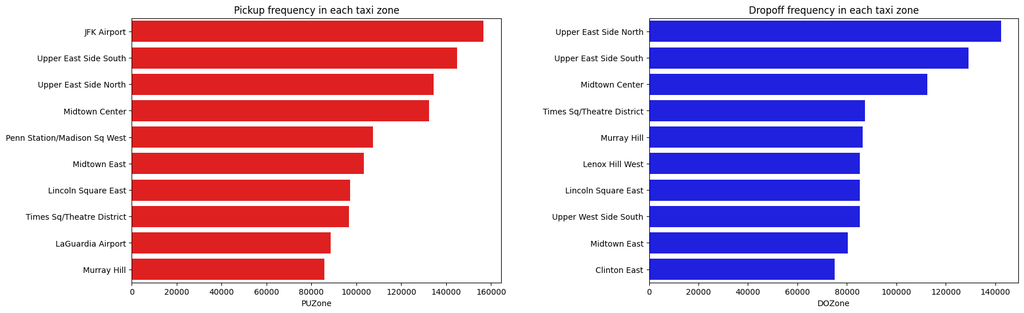

```python
fig, ax = plt.subplots(1, 2, figsize=(20, 6))
plt.subplots_adjust(wspace=0.4)

# The frequency on Pickup zone
sns.barplot(y=PUZone_fre.nlargest(10).index, x = PUZone_fre.nlargest(10), ax=ax[0], color='red')
ax[0].set_title('Pickup frequency in each taxi zone')

# The frequency on Dropoff zone
sns.barplot(y=DOZone_fre.nlargest(10).index, x = DOZone_fre.nlargest(10), ax=ax[1], color='blue')
ax[1].set_title('Dropoff frequency in each taxi zone')

plt.show()
```

# **Task 4: Data Analysis**

## **1. Rank the vendors by popularity**

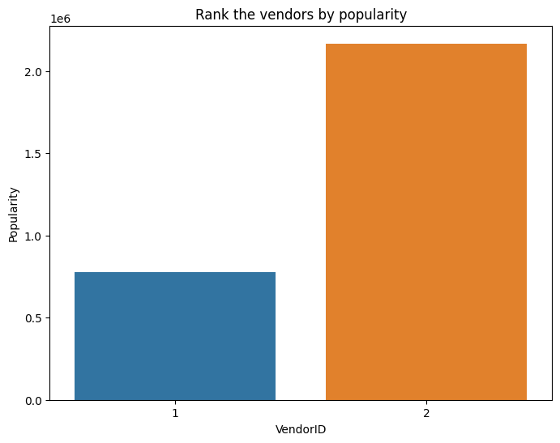

```python
# Plot the VendorID by popularity
fig, ax = plt.subplots(figsize=(8,6))
plt.subplots_adjust(wspace=0.4)

# Count plot on VendorID
sns.countplot(x=data['VendorID'], ax=ax)
plt.title('Rank the vendors by popularity')
plt.xlabel('VendorID')
plt.ylabel('Popularity')
plt.show()
```

It is clear that VendorID with value 2 have more than 2 times in popularity compare with VendorID with value 1. Which means that VeriFone Inc (code 2) is used more than Creative Mobile Technologies (code 1)

## **2. What are the peak travel hours?**

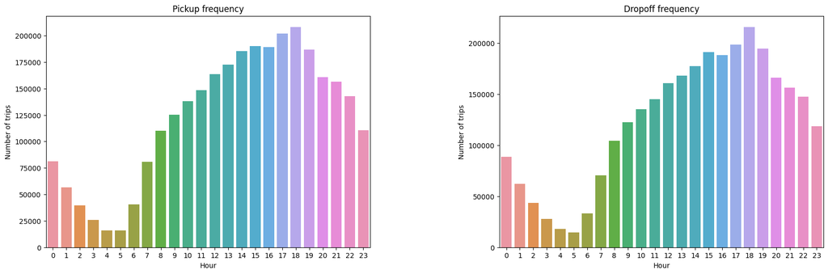

```python
# Plot the peak travel hours
fig, ax = plt.subplots(1, 2, figsize=(20, 6))
plt.subplots_adjust(wspace=0.4)

# The plot on frequency of pickup time
sns.countplot(x=data['tpep_pickup_datetime'].dt.hour, ax=ax[0])
ax[0].set_title('Pickup frequency')
ax[0].set_xlabel('Hour')
ax[0].set_ylabel('Number of trips')

# The plot on frequency of dropoff time
sns.countplot(x=data['tpep_dropoff_datetime'].dt.hour, ax=ax[1])
ax[1].set_title('Dropoff frequency')
ax[1].set_xlabel('Hour')
ax[1].set_ylabel('Number of trips')

plt.show()
```

The peak travel hours is 6pm (18 hour) for both pickup or dropoff

## **3. What is the average distance of the trips on weekdays and weekends?**

```python
weekdays = [0, 1, 2, 3, 4]
weekends = [5, 6]

# Feature to check if the day of trip is weekdays or weekends
data['dayofweek'] = data.apply(lambda x: 'weekday' if x['tpep_pickup_datetime'].dayofweek in weekdays else 'weekend', axis=1)

# Get the average miles for weekdays and weekends
Average_trip_weekday = data[data['dayofweek'] == 'weekday']['trip_distance'].mean()
Average_trip_weekend = data[data['dayofweek'] == 'weekend']['trip_distance'].mean()
print('The average distance of the trips on weekdays is:', round(Average_trip_weekday, 2), 'miles')
print('The average distance of the trips on weekends is:', round(Average_trip_weekend, 2), 'miles')
```

```
The average distance of the trips on weekdays is: 3.35 miles
The average distance of the trips on weekends is: 3.5 miles
```

The average distance of the trip on weekends is longer than average distance of the trip on weekdays, with have value 3.5 miles and 3.35 miles respectively.

## **4. What is the average number of passengers in a trip on weekdays and weekends?**

```python
# Get the average passengers for weekdays and weekends
Average_passengers_weekday = data[data['dayofweek'] == 'weekday']['passenger_count'].mean()
Average_passengers_weekend = data[data['dayofweek'] == 'weekend']['passenger_count'].mean()
print('The average passenger of the trips on weekdays is:', round(Average_passengers_weekday, 2), 'passengers')
print('The average passenger of the trips on weekends is:', round(Average_passengers_weekend, 2), 'passengers')
```

```
The average passenger of the trips on weekdays is: 1.33 passengers
The average passenger of the trips on weekends is: 1.45 passengers
```

The average number of passenger in a trip on weekends is more than average number of passenger in the trip on weekdays, with have value 1.45 passengers and 1.33 passengers respectively.

## **5. What is the correlation between the fare about and the tip?**

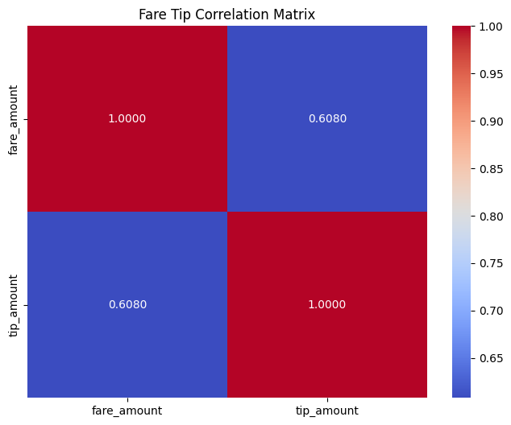

```python
# Correlation matrix between fare_amount and tip_amount
fare_tip = data[['fare_amount', 'tip_amount']]
plt.figure(figsize=(8, 6))
sns.heatmap(fare_tip.corr(), annot=True, cmap='coolwarm', fmt=".4f")
plt.title("Fare Tip Correlation Matrix")
plt.show()
```

The correlation between `fare amount` and `tip amount` seem quite strong with score **0.6080**, which is the strong possitive relationship between `fare amount` and `tip amount`. Thus, if `fare amount` increase, `tip amount` should increase

## **6. What is the correlation between the fare amount and the number of passengers?**

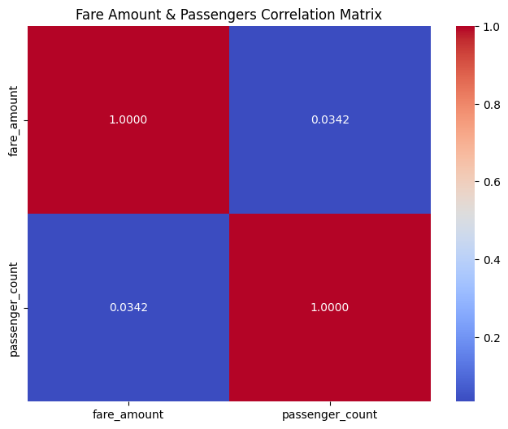

```python
# Correlation matrix between fare_amount and number of passengers
fare_passenger = data[['fare_amount', 'passenger_count']]
plt.figure(figsize=(8, 6))
sns.heatmap(fare_passenger.corr(), annot=True, cmap='coolwarm', fmt=".4f")
plt.title("Fare Amount & Passengers Correlation Matrix")
plt.show()
```

The correlation between `fare amount` and `number of passengers` seem very week with score **0.0342**, meaning these 2 variables do not have the linear relationship with the other. Thus, if `fare amount` would not incease, even `number of passenger` have significant elevate.

# **Task 5: Conclusion**

**2. Reflect on any challenges you faced during the analysis.**

- Challenge 1: The data of January include an significant amount of outliers and Null value, that make the process become harder on choosing the way to handle it.
- Challenge 2: Comparing the complexity between the straight line distance and trip distance, I need to merge the data and understand the unit of geometry data. However, the geometry data do not include any unit, so that make some trouble.

**3. Suggest possible next steps or additional analyses that could be performed**

- Possible analyses:
1. Handling all the missing value, try to find the way to deal with the outliers, to compare the effect with this approach.
2. Analyses the different on income that gain in the different hours, so we can have more specific views on when the income have been collect most.
3. Analyses the different on the income that is gain in different zone, so bases on it, the taxi can be distributed again to make it optimise for services and gain more money.
4. Get the new feature to check if that day is holiday or not, to see the differences between holiday and normal day.
5. Get 2 features that are rating per trip to analyse the fealing of the passengers and the tip amounts.